# work_arden

2026-02-25

# Libraries

```r
library(tidyverse)
library(janitor)
```

```r
library(ggplot2)
```

# Summary

Exploration data analysis of egg laying preferences of butterflies based on correlations to ambient temperature, nitrogen content of host plant, etc. Number of eggs on host plant decided as indicator of preferences (the more eggs laid on the plant, the stronger the suggsted preference).  
Analysis was conducted by plotting at least two plots per relationship:  
1. **Boxplot**: Plots if variable affects the decision to lay eggs at all. “Yes” indicates presence of eggs on plant. “No” indicates no eggs found on plant. 2. **Line Plot**: Shows if variable affects how strongly butterflies prefer the plant, if at all, indicated by the trend line formed.  
Additional plots were made for alternative presentation and analysis of data for the final project.

# Data

I used the egg laying data from [William B.V. Langdon, Richard Fox, Owen T. Lewis, Host plant use is driven by microclimate not nutritional quality in a grassland butterfly](https://doi.org/10.1101/2025.11.15.688506). The original research article and data sets are included in the data folder in this repository.

```r
egg_laying <- read_csv("data/egg_laying_data.csv") %>%
  clean_names()
```

# Data Analysis Proper

## Ambient Temperature

Analysis of relationship between number of eggs found on plants and ambient temperature. **Plots were scrapped** due to incomplete temperature range as there were no plot points at a range of 18°C and 24°C.

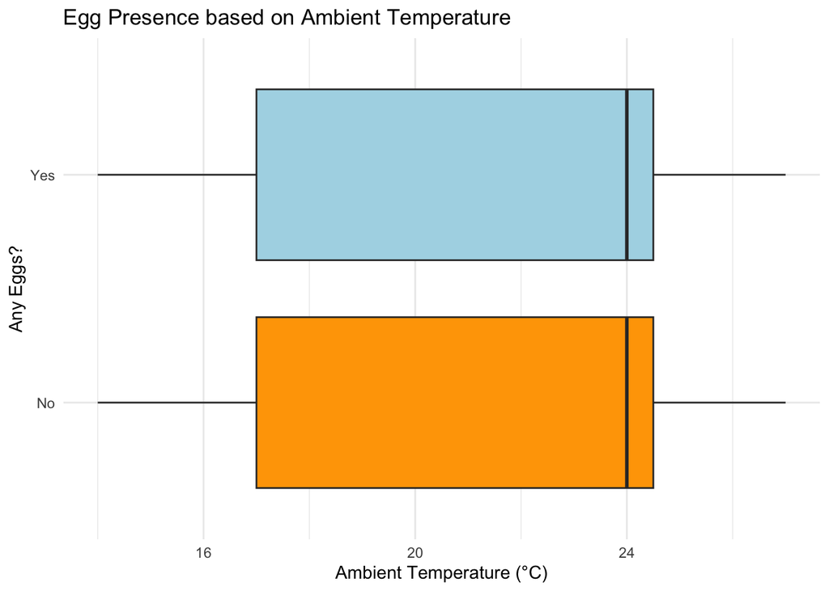

```r
# Box Plot
egg_laying %>%
  select(temperature_ambient, n_eggs) %>%
  mutate(lay_eggs = if_else(n_eggs > 0, "Yes", "No")) %>%
  ggplot(aes(x = lay_eggs, y = temperature_ambient, fill = lay_eggs)) +
  geom_boxplot() +
  scale_fill_manual(values = c("Yes" = "lightblue", "No" = "orange")) +
  coord_flip() +
  theme_minimal() +
  theme(legend.position = "none") +
  labs(
    title = "Egg Presence based on Ambient Temperature",
    x = "Any Eggs?",
    y = "Ambient Temperature (°C)"
    )
```

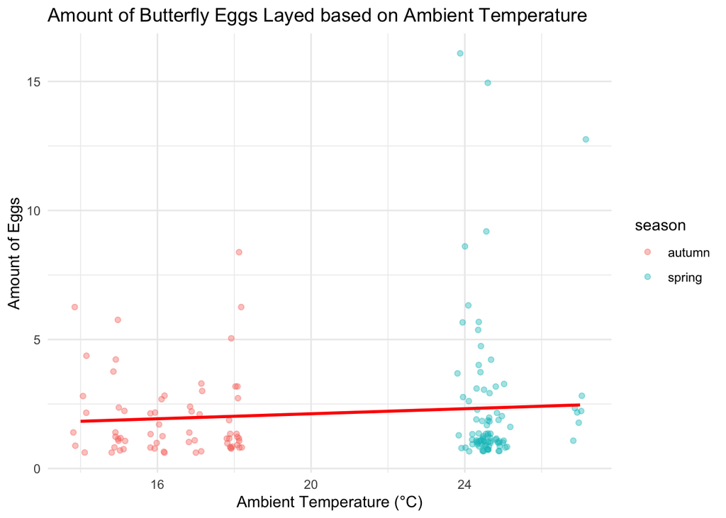

```r
# Line Plot
egg_laying %>%
  filter(n_eggs != 0) %>%
  ggplot(aes(x = temperature_ambient, y = n_eggs, color = season)) +
  geom_jitter(alpha = 0.4) +
  geom_smooth(method = "lm", se = FALSE, color = "red") +
  theme_minimal() +
  labs(
    title = "Amount of Butterfly Eggs Layed based on Ambient Temperature",
    x = "Ambient Temperature (°C)",
    y = "Amount of Eggs"
  )
```

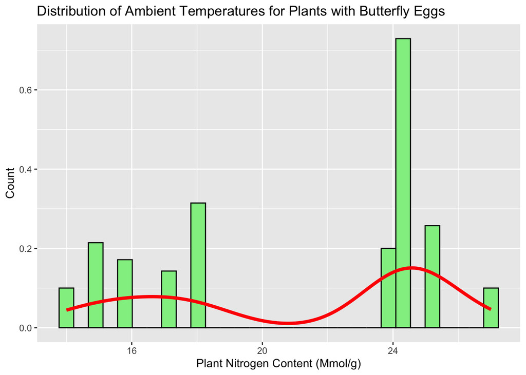

```r
# Histogram and Density Plot
egg_laying %>%
  filter(n_eggs != 0) %>%
  ggplot(aes(x = temperature_ambient)) +
  geom_histogram(aes(y = after_stat(density)), color = "black", fill = "lightgreen") +
  geom_density(color = "red", alpha = 0.4, size = 1.5) +
  labs(
    title = "Distribution of Ambient Temperatures for Plants with Butterfly Eggs",
    x = "Plant Nitrogen Content (Mmol/g)",
    y = "Count"
  )
```

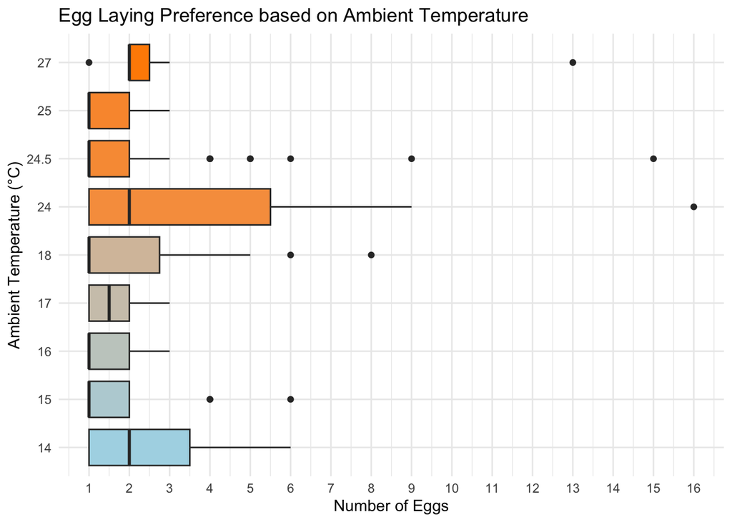

```r
egg_laying %>%
  select(temperature_ambient, n_eggs) %>%
  filter(n_eggs != 0) %>%
  mutate(temperature_ambient = as.factor(temperature_ambient)) %>%
  ggplot(aes(x = temperature_ambient, y = n_eggs, fill = as.numeric(as.character(temperature_ambient)))) +
  geom_boxplot() +
  scale_y_continuous(
    breaks = seq(0, 16, by = 1)  # Tick every 10 units
  ) +
  coord_flip() +
  theme_minimal() +
  scale_fill_gradient(low = "lightblue", high = "darkorange") +
  theme(
    legend.position = "none"
    ) +
  labs(
    title = "Egg Laying Preference based on Ambient Temperature",
    x = "Ambient Temperature (°C)",
    y = "Number of Eggs"
  )
```

## Nitrogen Content Analysis of relationship between number of eggs found on plants and host plant nitrogen content.

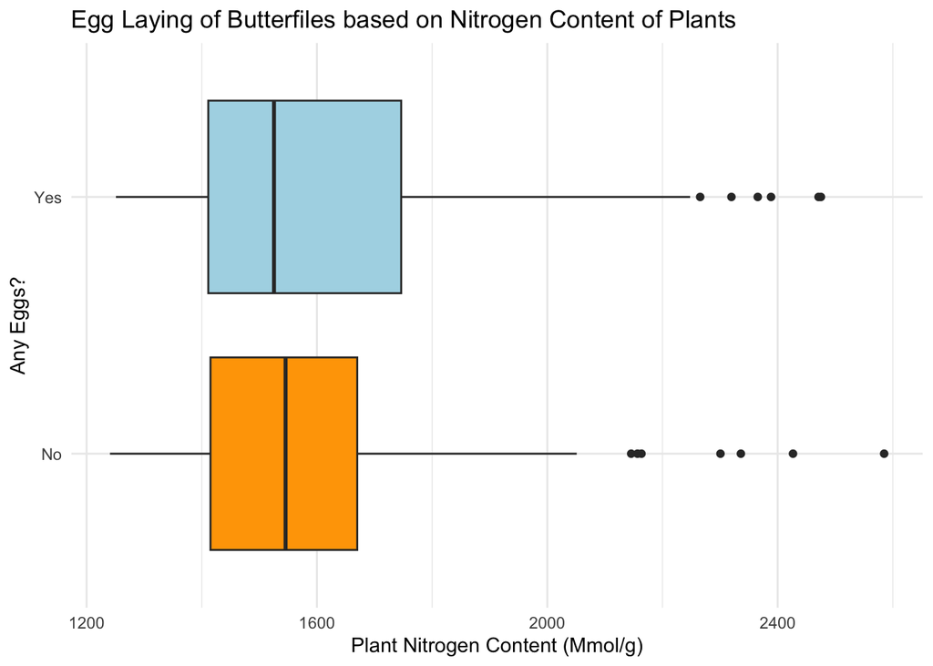

```r
# Box plot
egg_laying %>%
  select(predicted_n, n_eggs) %>%
  mutate(lay_eggs = if_else(n_eggs > 0, "Yes", "No")) %>%
  ggplot(aes(x = lay_eggs, y = predicted_n, fill = lay_eggs)) +
  geom_boxplot() +
  scale_fill_manual(values = c("Yes" = "lightblue", "No" = "orange")) +
  coord_flip() +
  theme_minimal() +
  theme(legend.position = "none") +
  labs(
    title = "Egg Laying of Butterfiles based on Nitrogen Content of Plants",
    x = "Any Eggs?",
    y = "Plant Nitrogen Content (Mmol/g)"
    )
```

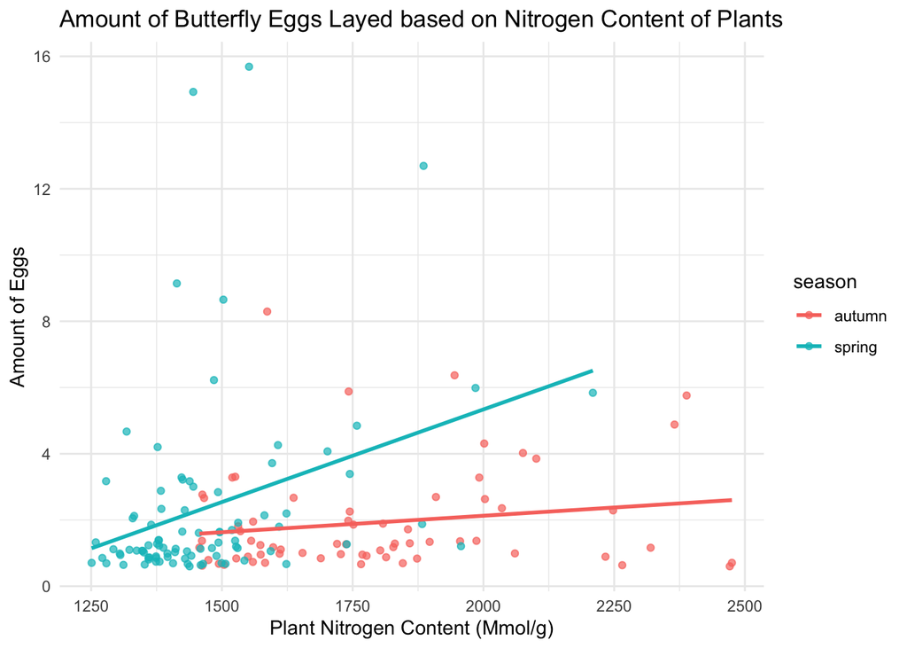

```r
# Line Plot
egg_laying %>%
  filter(n_eggs != 0) %>%
  ggplot(aes(x = predicted_n, y = n_eggs, color = season)) +
  geom_jitter(alpha = 0.7) +
  geom_smooth(method = "lm", se = FALSE) +
  theme_minimal() +
  labs(
    title = "Amount of Butterfly Eggs Layed based on Nitrogen Content of Plants",
    x = "Plant Nitrogen Content (Mmol/g)",
    y = "Amount of Eggs"
  )
```

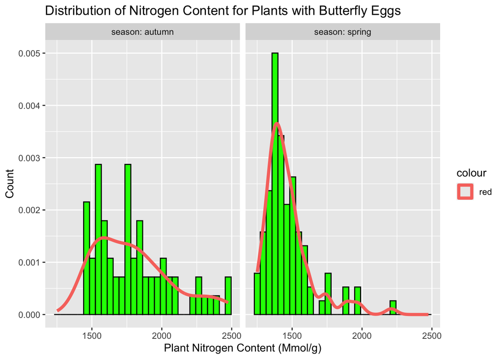

```r
# Histogram and Density Plot
egg_laying %>%
  filter(n_eggs != 0) %>%
  ggplot(aes(x = predicted_n)) +
  geom_histogram(aes(y = after_stat(density), group = season), color = "black", fill = "green") +
  geom_density(aes(color = "red"), alpha = 0.4, size = 1.5) +
  facet_grid(~season, labeller = label_both) +
  labs(
    title = "Distribution of Nitrogen Content for Plants with Butterfly Eggs",
    x = "Plant Nitrogen Content (Mmol/g)",
    y = "Count"
  )
```

## Leaf Size Analysis of relationship between number of eggs found on plants and average host plant leaf size.

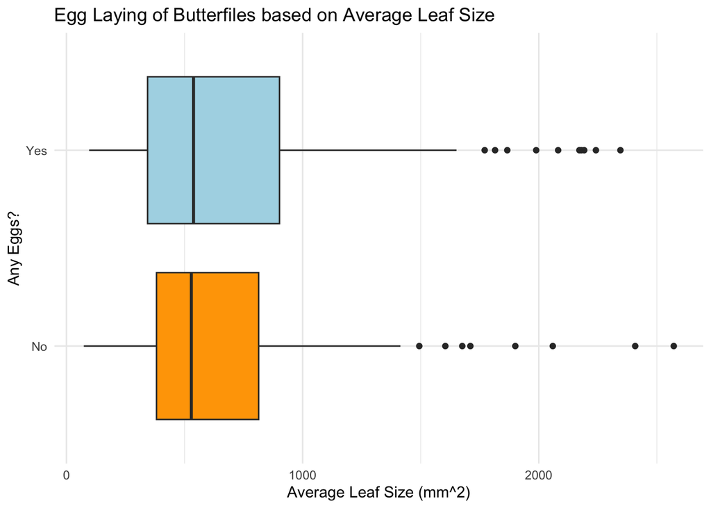

```r
# Box Plot
egg_laying %>%
  select(average_leaf_size, n_eggs) %>%
  mutate(lay_eggs = if_else(n_eggs > 0, "Yes", "No")) %>%
  ggplot(aes(x = lay_eggs, y = average_leaf_size, fill = lay_eggs)) +
  geom_boxplot() +
  scale_fill_manual(values = c("Yes" = "lightblue", "No" = "orange")) +
  coord_flip() +
  theme_minimal() +
  theme(legend.position = "none") +
  labs(
    title = "Egg Laying of Butterfiles based on Average Leaf Size",
    x = "Any Eggs?",
    y = "Average Leaf Size (mm^2)"
    )
```

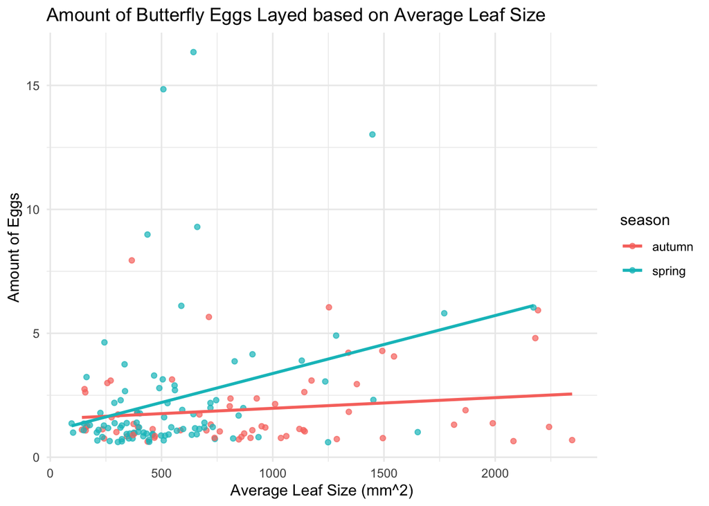

```r
# Line Plot
egg_laying %>%
  filter(n_eggs != 0) %>%
  ggplot(aes(x = average_leaf_size, y = n_eggs, color = season)) +
  geom_jitter(alpha = 0.7) +
  geom_smooth(method = "lm", se = FALSE) +
  theme_minimal() +
  labs(
    title = "Amount of Butterfly Eggs Layed based on Average Leaf Size",
    x = "Average Leaf Size (mm^2)",
    y = "Amount of Eggs"
  )
```

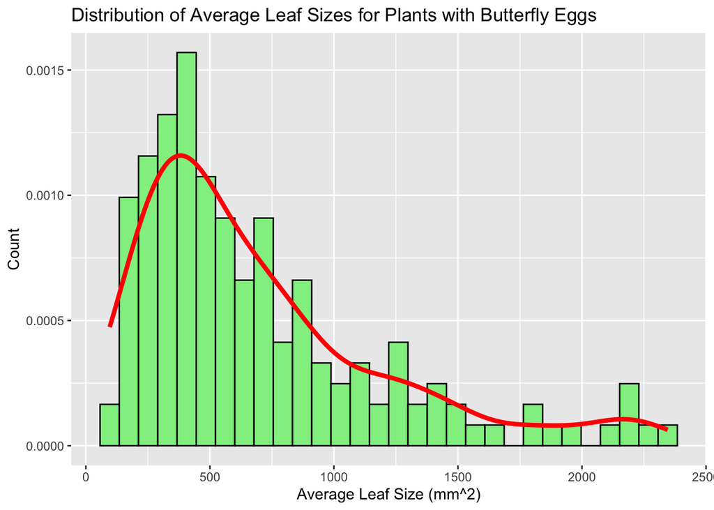

```r
# Histogram and Density Plot
egg_laying %>%
  filter(n_eggs != 0) %>%
  ggplot(aes(x = average_leaf_size)) +
  geom_histogram(aes(y = after_stat(density)), color = "black", fill = "lightgreen") +
  geom_density(color = "red", alpha = 0.4, size = 1.5) +
  labs(
    title = "Distribution of Average Leaf Sizes for Plants with Butterfly Eggs",
    x = "Average Leaf Size (mm^2)",
    y = "Count"
  )
```

## Vegetation around Plant Analysis of relationship between number of eggs found on plants and vegetation surrounding host plant in a 50 cm x 50 cm area.

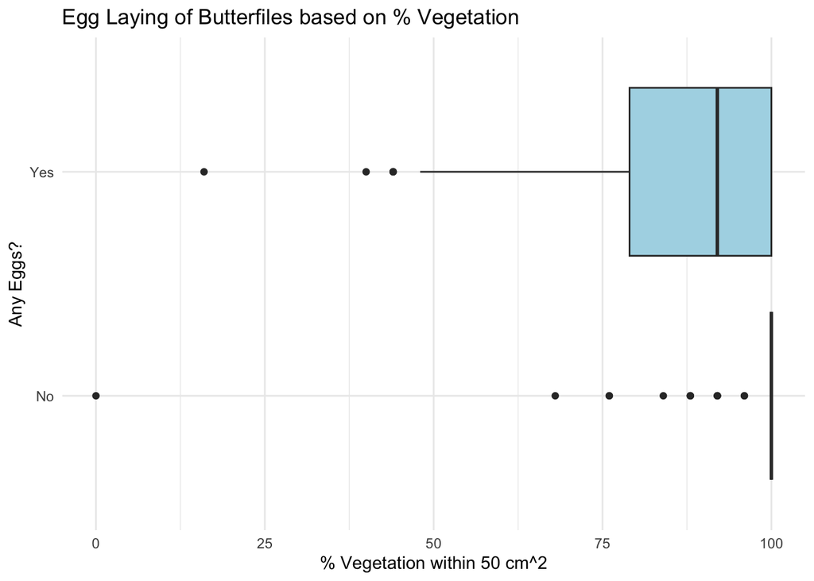

```r
# Box Plot
egg_laying %>%
  select(veg, n_eggs) %>%
  mutate(lay_eggs = if_else(n_eggs > 0, "Yes", "No")) %>%
  ggplot(aes(x = lay_eggs, y = veg, fill = lay_eggs)) +
  geom_boxplot() +
  scale_fill_manual(values = c("Yes" = "lightblue", "No" = "orange")) +
  coord_flip() +
  theme_minimal() +
  theme(legend.position = "none") +
  labs(
    title = "Egg Laying of Butterfiles based on % Vegetation",
    x = "Any Eggs?",
    y = "% Vegetation within 50 cm^2"
    )
```

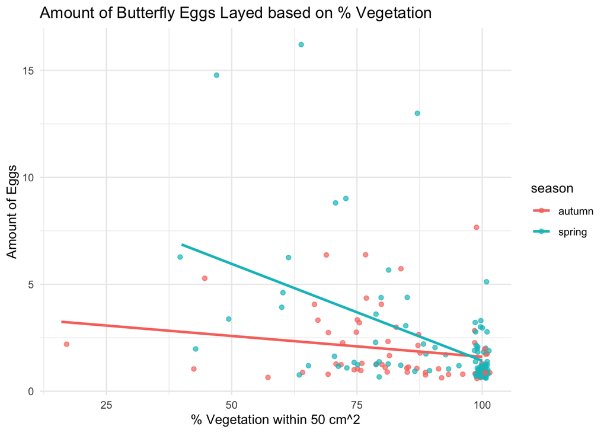

```r
# Line Plot
egg_laying %>%
  filter(n_eggs != 0) %>%
  ggplot(aes(x = veg, y = n_eggs, color = season)) +
  geom_jitter(alpha = 0.7) +
  geom_smooth(method = "lm", se = FALSE) +
  theme_minimal() +
  labs(
    title = "Amount of Butterfly Eggs Layed based on % Vegetation",
    x = "% Vegetation within 50 cm^2",
    y = "Amount of Eggs"
  )
```

## Bare Ground Analysis of relationship between number of eggs found on plants and bare ground surrounding host plant in a 50 cm x 50 cm area.

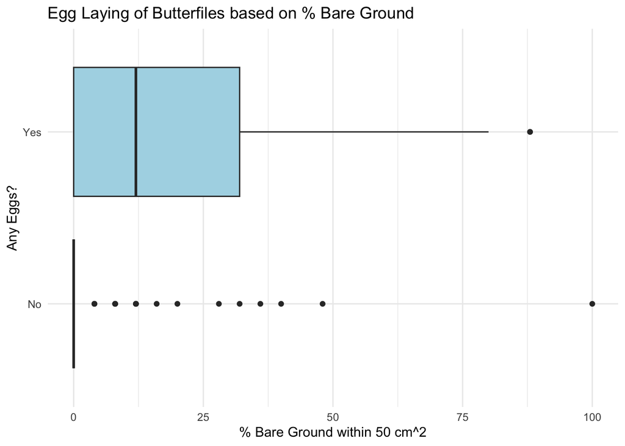

```r
# Box Plot
egg_laying %>%
  select(bare_ground, n_eggs) %>%
  mutate(lay_eggs = if_else(n_eggs > 0, "Yes", "No")) %>%
  ggplot(aes(x = lay_eggs, y = bare_ground, fill = lay_eggs)) +
  geom_boxplot() +
  scale_fill_manual(values = c("Yes" = "lightblue", "No" = "orange")) +
  coord_flip() +
  theme_minimal() +
  theme(legend.position = "none") +
  labs(
    title = "Egg Laying of Butterfiles based on % Bare Ground",
    x = "Any Eggs?",
    y = "% Bare Ground within 50 cm^2"
    )
```

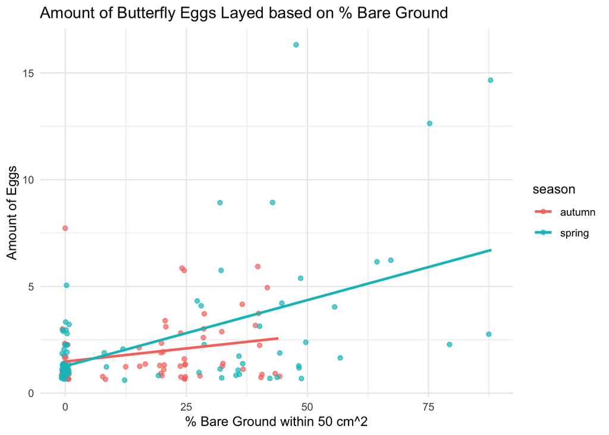

```r
# Line Plot
egg_laying %>%
  filter(n_eggs != 0) %>%
  ggplot(aes(x = bare_ground, y = n_eggs, color = season)) +
  geom_jitter(alpha = 0.7) +
  geom_smooth(method = "lm", se = FALSE) +
  theme_minimal() +
  labs(
    title = "Amount of Butterfly Eggs Layed based on % Bare Ground",
    x = "% Bare Ground within 50 cm^2",
    y = "Amount of Eggs"
  )
```